# Warriors_NLP_Word_Analysis

```python
!pip install tweepy
```

```python
!pip install textblob
```

```python
!pip install protobuf==3.20.1
```

```
  Attempting uninstall: protobuf
    Found existing installation: protobuf 3.15.7
    Uninstalling protobuf-3.15.7:
      Successfully uninstalled protobuf-3.15.7
```

```python
!pip install zeugma
```

[output not shown]

```python
!pip install --upgrade gensim
```

```
  Using cached gensim-4.2.0-cp38-cp38-win_amd64.whl (24.0 MB)
```

[output not shown]

```python
!python -m pip install gensim==4.2.0
```

```
  Attempting uninstall: Cython
    Found existing installation: Cython 0.29.21
    Uninstalling Cython-0.29.21:
```

[output not shown]

```python
!pip install pyLDAvis
```

[output not shown]

[output not shown]

[output not shown]

```python
!pip install glove_py
```

[output not shown]

[output not shown]

```python
!python -m pip install seaborn
```

```python
!python -m pip install wordcloud
```

```python
import sys
print(sys.executable)
```

```
C:\Users\tjame\anaconda3\python.exe
```

# Importing Libraries

```python
import gensim
import gzip
import json
import matplotlib.pyplot as plt
import numpy as np
import pickle
import re
import pandas as pd
from tqdm.notebook import tqdm
from gensim.models.word2vec import Word2Vec
from collections import Counter
from nltk.tokenize import sent_tokenize, word_tokenize
from gensim.test.utils import datapath
import pandas as pd
import tweepy as tw
import os
from tweepy import OAuthHandler
from textblob import TextBlob
from bs4 import BeautifulSoup
import nltk
from nltk.corpus import stopwords
import seaborn as sns
from collections import Counter, defaultdict
from sklearn.dummy import DummyClassifier
from sklearn.feature_extraction.text import TfidfVectorizer
from sklearn.linear_model import LogisticRegression
from sklearn.metrics import f1_score
from sklearn.model_selection import train_test_split
from sklearn.metrics import mean_squared_error, r2_score
from sklearn.linear_model import LinearRegression
from sklearn.decomposition import LatentDirichletAllocation
from sklearn.feature_extraction.text import CountVectorizer
from sklearn.preprocessing import Normalizer
from sklearn.decomposition import TruncatedSVD
from sklearn.metrics.pairwise import cosine_similarity
from wordcloud import WordCloud
from sklearn import decomposition
#import zeugma
#from zeugma.embeddings import EmbeddingTransformer
from gensim.utils import simple_preprocess
#from gensim.sklearn_api import W2VTransformer
import sklearn
from sklearn.base import BaseEstimator, TransformerMixin
import pyLDAvis.sklearn
import pyLDAvis
import pyLDAvis.gensim_models as gensimvis
%matplotlib inline
import seaborn as sns
from bs4 import BeautifulSoup
import requests
import re
```

```python
Word2Vec
```

```
gensim.models.word2vec.Word2Vec
```

```python
RANDOM_SEED = 655
```

# Extracting Data from Twitter

```python
# your Twitter API key and API secret
my_api_key = ""
my_api_secret = ""
# authenticate
auth = tw.OAuthHandler(my_api_key, my_api_secret)
api = tw.API(auth, wait_on_rate_limit=True)
```

# Selecting Keywords to be searched for in Twitter for the Golden State Warriors

```python
search_query_Warriors1 = "#GoldenStateWarriors -filter:retweets"
search_query_Warriors2 = "#StephenCurry30 -filter:retweets"
search_query_Warriors3 = "#Money23Green -filter:retweets"
search_query_Warriors4 = "#KlayThompson -filter:retweets"
search_query_Warriors5 = "#22wiggins -filter:retweets"
search_query_Warriors6 = "#Dubs -filter:retweets"
search_query_Warriors7 = "#dubs -filter:retweets"
search_query_Warriors8 = "#GoldenState -filter:retweets"
search_query_Warriors9 = "#goldenstate -filter:retweets"
search_query_Warriors10 = "#Golden_State -filter:retweets"
search_query_Warriors11 = "#golden_state -filter:retweets"
search_query_Warriors12 = "#SteveKerr -filter:retweets"
search_query_Warriors13 = "#kerr -filter:retweets"
search_query_Warriors14 = "#klaythompson -filter:retweets"
search_query_Warriors15 = "#warriors -filter:retweets"
search_query_Warriors16 = "#Wiggins -filter:retweets"
search_query_Warriors17 = "#stevekerr -filter:retweets"
search_query_Warriors18 = "#stevekerr -filter:retweets"
search_query_Warriors19 = "#StephCurry -filter:retweets"
```

# Importing Tweets from Twitter for selected date range

```python
# get tweets from the API
tweets_Warriors = tw.Cursor(api.search_tweets,
              q=search_query_Warriors1,
              lang="en",
              since="2021-08-06").items(2000)
# store the API responses in a list
tweets_copy_Warriors = []
for tweet in tweets_Warriors:
    tweets_copy_Warriors.append(tweet)

print("Total Tweets fetched:", len(tweets_copy_Warriors))
```

```python
# get tweets from the API
tweets_Warriors = tw.Cursor(api.search_tweets,
              q=search_query_Warriors2,
              lang="en",
              since="2021-08-06").items(2000)
# store the API responses in a list
for tweet in tweets_Warriors:
    tweets_copy_Warriors.append(tweet)

print("Total Tweets fetched:", len(tweets_copy_Warriors))
```

```python
# get tweets from the API
tweets_Warriors = tw.Cursor(api.search_tweets,
              q=search_query_Warriors3,
              lang="en",
              since="2021-08-06").items(2000)
# store the API responses in a list
for tweet in tweets_Warriors:
    tweets_copy_Warriors.append(tweet)

print("Total Tweets fetched:", len(tweets_copy_Warriors))
```

```python
# get tweets from the API
tweets_Warriors = tw.Cursor(api.search_tweets,
              q=search_query_Warriors4,
              lang="en",
              since="2021-08-06").items(2000)
# store the API responses in a list
for tweet in tweets_Warriors:
    tweets_copy_Warriors.append(tweet)

print("Total Tweets fetched:", len(tweets_copy_Warriors))
```

```python
# get tweets from the API
tweets_Warriors = tw.Cursor(api.search_tweets,
              q=search_query_Warriors5,
              lang="en",
              since="2021-08-06").items(2000)
# store the API responses in a list
for tweet in tweets_Warriors:
    tweets_copy_Warriors.append(tweet)

print("Total Tweets fetched:", len(tweets_copy_Warriors))
```

```python
# get tweets from the API
tweets_Warriors = tw.Cursor(api.search_tweets,
              q=search_query_Warriors6,
              lang="en",
              since="2021-08-06").items(2000)
# store the API responses in a list
for tweet in tweets_Warriors:
    tweets_copy_Warriors.append(tweet)

print("Total Tweets fetched:", len(tweets_copy_Warriors))
```

```python
# get tweets from the API
tweets_Warriors = tw.Cursor(api.search_tweets,
              q=search_query_Warriors7,
              lang="en",
              since="2021-08-06").items(2000)
# store the API responses in a list
for tweet in tweets_Warriors:
    tweets_copy_Warriors.append(tweet)

print("Total Tweets fetched:", len(tweets_copy_Warriors))
```

```python
# get tweets from the API
tweets_Warriors = tw.Cursor(api.search_tweets,
              q=search_query_Warriors8,
              lang="en",
              since="2021-08-06").items(2000)
# store the API responses in a list
for tweet in tweets_Warriors:
    tweets_copy_Warriors.append(tweet)

print("Total Tweets fetched:", len(tweets_copy_Warriors))
```

```python
# get tweets from the API
tweets_Warriors = tw.Cursor(api.search_tweets,
              q=search_query_Warriors8,
              lang="en",
              since="2021-08-06").items(2000)
# store the API responses in a list
for tweet in tweets_Warriors:
    tweets_copy_Warriors.append(tweet)

print("Total Tweets fetched:", len(tweets_copy_Warriors))
```

```python
# get tweets from the API
tweets_Warriors = tw.Cursor(api.search_tweets,
              q=search_query_Warriors9,
              lang="en",
              since="2021-08-06").items(2000)
# store the API responses in a list
for tweet in tweets_Warriors:
    tweets_copy_Warriors.append(tweet)

print("Total Tweets fetched:", len(tweets_copy_Warriors))
```

```python
# get tweets from the API
tweets_Warriors = tw.Cursor(api.search_tweets,
              q=search_query_Warriors10,
              lang="en",
              since="2021-08-06").items(2000)
# store the API responses in a list
for tweet in tweets_Warriors:
    tweets_copy_Warriors.append(tweet)

print("Total Tweets fetched:", len(tweets_copy_Warriors))
```

```python
# get tweets from the API
tweets_Warriors = tw.Cursor(api.search_tweets,
              q=search_query_Warriors11,
              lang="en",
              since="2021-08-06").items(2000)
# store the API responses in a list
for tweet in tweets_Warriors:
    tweets_copy_Warriors.append(tweet)

print("Total Tweets fetched:", len(tweets_copy_Warriors))
```

```python
# get tweets from the API
tweets_Warriors = tw.Cursor(api.search_tweets,
              q=search_query_Warriors12,
              lang="en",
              since="2021-08-06").items(2000)
# store the API responses in a list
for tweet in tweets_Warriors:
    tweets_copy_Warriors.append(tweet)

print("Total Tweets fetched:", len(tweets_copy_Warriors))
```

```python
# get tweets from the API
tweets_Warriors = tw.Cursor(api.search_tweets,
              q=search_query_Warriors13,
              lang="en",
              since="2021-08-06").items(2000)
# store the API responses in a list
for tweet in tweets_Warriors:
    tweets_copy_Warriors.append(tweet)

print("Total Tweets fetched:", len(tweets_copy_Warriors))
```

```python
# get tweets from the API
tweets_Warriors = tw.Cursor(api.search_tweets,
              q=search_query_Warriors14,
              lang="en",
              since="2021-08-06").items(2000)
# store the API responses in a list
for tweet in tweets_Warriors:
    tweets_copy_Warriors.append(tweet)

print("Total Tweets fetched:", len(tweets_copy_Warriors))
```

```python
# get tweets from the API
tweets_Warriors = tw.Cursor(api.search_tweets,
              q=search_query_Warriors15,
              lang="en",
              since="2021-08-06").items(2000)
# store the API responses in a list
for tweet in tweets_Warriors:
    tweets_copy_Warriors.append(tweet)

print("Total Tweets fetched:", len(tweets_copy_Warriors))
```

```python
# get tweets from the API
tweets_Warriors = tw.Cursor(api.search_tweets,
              q=search_query_Warriors16,
              lang="en",
              since="2021-08-06").items(2000)
# store the API responses in a list
for tweet in tweets_Warriors:
    tweets_copy_Warriors.append(tweet)

print("Total Tweets fetched:", len(tweets_copy_Warriors))
```

```python
# get tweets from the API
tweets_Warriors = tw.Cursor(api.search_tweets,
              q=search_query_Warriors17,
              lang="en",
              since="2021-08-06").items(2000)
# store the API responses in a list
for tweet in tweets_Warriors:
    tweets_copy_Warriors.append(tweet)

print("Total Tweets fetched:", len(tweets_copy_Warriors))
```

```python
# get tweets from the API
tweets_Warriors = tw.Cursor(api.search_tweets,
              q=search_query_Warriors18,
              lang="en",
              since="2021-08-06").items(2000)
# store the API responses in a list
for tweet in tweets_Warriors:
    tweets_copy_Warriors.append(tweet)

print("Total Tweets fetched:", len(tweets_copy_Warriors))
```

```python
# get tweets from the API
tweets_Warriors = tw.Cursor(api.search_tweets,
              q=search_query_Warriors19,
              lang="en",
              since="2021-08-06").items(2000)
# store the API responses in a list
for tweet in tweets_Warriors:
    tweets_copy_Warriors.append(tweet)

print("Total Tweets fetched:", len(tweets_copy_Warriors))
```

# Creating a dataframe for extracted tweets

```python
# intialize the dataframe
import pandas as pd
tweets_df_Warriors = pd.DataFrame()
# populate the dataframe
for tweet in tweets_copy_Warriors:
    hashtags = []
    try:
        for hashtag in tweet.entities["hashtags"]:
            hashtags.append(hashtag["text"])
        text = api.get_status(id=tweet.id, tweet_mode='extended').full_text
    except:
        pass
    tweets_df_Warriors = tweets_df_Warriors.append(pd.DataFrame({'user_name': tweet.user.name,
                                                                 'user_location': tweet.user.location,\
                                                                 'user_description': tweet.user.description,
                                                                 'user_verified': tweet.user.verified,
                                                                  'date': tweet.created_at,
                                                                  'text': text,
                                                                  'hashtags': [hashtags if hashtags else None],
                                                                  'source': tweet.source}))
    tweets_df_Warriors = tweets_df_Warriors.reset_index(drop=True)
# show the dataframe
tweets_df_Warriors.head(10)
```

# Importing of Tweets previously extracted and saved to a csv file

```python
#tweets_df_Warriors.to_csv('tweets_df_Warriors1.csv')
tweets_df_Warriors = pd.read_csv('tweets_df_Warriors1.csv')
```

```python
Warriors_tweet_texts = tweets_df_Warriors['text']
Warriors_text_sources = tweets_df_Warriors['source']
d = {'Warriors_Tweet_Text':Warriors_tweet_texts, 'Warriors_Text_Source':Warriors_text_sources}
Warriors_tweet_df = pd.DataFrame(data=d)
Warriors_tweet_df.head()
```

|  | Warriors_Tweet_Text | Warriors_Text_Source |
| --- | --- | --- |
| 0 | #draymond When #Poole #party #OAYO @louiestopp... | Twitter for Android |
| 1 | I know the 'participation trophy' crowd will d... | Twitter for Android |
| 2 | @Money23Green out of control 😂😂😂 #GoldenState... | Twitter for iPhone |
| 3 | Draymond sucks for more things than sucker pun... | Twitter for Android |
| 4 | Made this little dude and customized it for ea... | love.nba |

# Cleaning the data

```python
Warriors_tweet_df['Warriors_Tweet_Text'] = Warriors_tweet_df['Warriors_Tweet_Text'].apply(lambda x: x.lower())
```

```python
Warriors_tweet_df['Warriors_Tweet_Text'] = Warriors_tweet_df['Warriors_Tweet_Text'].apply(lambda x: BeautifulSoup(x, 'html.parser').get_text())
Warriors_tweet_df['Warriors_Tweet_Text'] = Warriors_tweet_df['Warriors_Tweet_Text'].apply(lambda x: ' '.join(re.sub("(@[A-Za-z0-9]+)|([^0-9A-Za-z \t])|(\w+:\/\/\S+)", " ", x).split()))
```

```python
Warriors_tweet_df.head()
```

|  | Warriors_Tweet_Text | Warriors_Text_Source |
| --- | --- | --- |
| 0 | draymond when poole party oayo draymondgreen j... | Twitter for Android |
| 1 | i know the participation trophy crowd will dis... | Twitter for Android |
| 2 | out of control goldenstatewarriors nba draymon... | Twitter for iPhone |
| 3 | draymond sucks for more things than sucker pun... | Twitter for Android |
| 4 | made this little dude and customized it for ea... | love.nba |

# Utilizing NLP's word_tokenize to split the Warriors' list of tweets into words using a tqdm to speed up the process

```python
nltk.download('punkt')
```

```
True
```

```python
nltk_tokenized_Warriors_tweet_texts = []

for Warriors_tweet_text in tqdm(Warriors_tweet_texts):
    nltk_tokenized_Warriors_tweet_texts.append(word_tokenize(Warriors_tweet_text))
```

# Comparing the NLTK tokenization to a regular-expression based extraction

```python
re_tokenized_Warriors_tweet_texts = []

for Warriors_tweet_text in tqdm(Warriors_tweet_texts):
    word_splitter = re.findall(r"\w+",Warriors_tweet_text)
    re_tokenized_Warriors_tweet_texts.append(word_splitter)
```

# Count how many unique tokens were found from the NLTK and RegEx methods

```python
nltk_word_counts = Counter()
re_word_counts = Counter()

for Warriors_tweet_text in nltk_tokenized_Warriors_tweet_texts:
    for wor in Warriors_tweet_text:
        nltk_word_counts[wor]+=1
for b in re_tokenized_Warriors_tweet_texts:
    for w in b:
        re_word_counts[w]+=1
```

```python
len(nltk_word_counts), len(re_word_counts)
```

```
(14949, 13949)
```

# Identify the 20 most common words that were missed through the imprecision of RegEx matching

```python
unique_word_counts = nltk_word_counts.copy()
for x in nltk_word_counts:
    if re_word_counts[x] != 0:
        del unique_word_counts[x]
```

```python
unique_word_counts1 = Counter(unique_word_counts).most_common(20)
unique_word_counts1
```

```
[('#', 28773),
 (':', 6378),
 ('.', 2077),
 ('@', 1686),
 ('!', 1417),
 (',', 1375),
 ('’', 922),
 ('?', 528),
 ('...', 508),
 (';', 426),
 ('&', 363),
 ("'s", 357),
 ("''", 318),
 ('|', 224),
 (')', 211),
 ('(', 207),
 ('“', 179),
 ("'", 163),
 ('-', 161),
 ("n't", 146)]
```

```python
len(unique_word_counts)
```

```
3961
```

# We are mostly missing only punctuations and abbreviations. This is efficient for better text analyses. The NLTK method will be selected for this project as the better quality analysis.

```python
all_tokenized_Warriors_tweet_texts = nltk_tokenized_Warriors_tweet_texts
word_counts = nltk_word_counts
```

```python
len(word_counts)
```

```
14949
```

# Record all lower-case word counts and print the number of unique words. How many upper-case words did we learn?

```python
lowercase_word_counts = {k.lower(): v for k, v in word_counts.items()}
```

```python
len(word_counts), len(lowercase_word_counts)
```

```
(14949, 12815)
```

```python
word_case_difference = abs((len(word_counts))-(len(lowercase_word_counts)))
word_case_difference
```

```
2134
```

# Train a Word2Vec Model on the Golden State Warriors tokenized twitter data

```python
quick_model = Word2Vec(sentences=all_tokenized_Warriors_tweet_texts, vector_size=50, window=2, min_count=100, workers=4, seed=RANDOM_SEED)
```

```python
quick_word_vectors = quick_model.wv
```

```python
quick_word_vectors.similar_by_word("Warriors")[:10]
```

```
[('Baldwin', 0.7773249745368958),
 ('NBA', 0.7228875160217285),
 ('New', 0.7007817029953003),
 ('Video', 0.6907162070274353),
 ('Japan', 0.6882004737854004),
 ('GoldenState', 0.6733344197273254),
 ("'", 0.6715351343154907),
 ('StrengthInNumbers', 0.6572862863540649),
 ('LetsGoWarriors', 0.6451500058174133),
 ('|', 0.6390395164489746)]
```

```python
quick_word_vectors.similar_by_word("StrengthInNumbers")[:10]
```

```
[('LetsGoWarriors', 0.9383447766304016),
 ('GoldenState', 0.9248340129852295),
 ('Dubs', 0.9205941557884216),
 ('DubNation', 0.8794711232185364),
 ('GSW', 0.8413811922073364),
 ('GoldenStateWarriors', 0.8321093320846558),
 ('Rumors', 0.8186068534851074),
 ('California', 0.7507092356681824),
 ('PacificDivision', 0.6992496252059937),
 ('https', 0.6852337121963501)]
```

```python
quick_word_vectors.similar_by_word("GoldenState")[:10]
```

```
[('LetsGoWarriors', 0.9271683692932129),
 ('StrengthInNumbers', 0.9248340725898743),
 ('GSW', 0.9128663539886475),
 ('DubNation', 0.8999127745628357),
 ('Dubs', 0.8939521908760071),
 ('GoldenStateWarriors', 0.8247516751289368),
 ('Rumors', 0.8151276707649231),
 ('California', 0.7486129403114319),
 ('JordanPoole', 0.7303376197814941),
 ('PacificDivision', 0.7297829389572144)]
```

# Using Bag-of-Words to transform the list of strings from the Twitter tweets into a numeric document-term matrix

```python
Warriors_Tweet_Text = Warriors_tweet_df['Warriors_Tweet_Text']
tf_vectorizer = CountVectorizer(stop_words = 'english')
tf_documents = tf_vectorizer.fit_transform(Warriors_Tweet_Text)

print("doc-term matrix shape:", tf_documents.shape)
print("doc-term matrix initial row (first document vector):\n",
tf_documents[0:1])
```

```
doc-term matrix shape: (4714, 8195)
doc-term matrix initial row (first document vector):
   (0, 2222)	1
  (0, 5552)	1
  (0, 5338)	1
  (0, 5129)	1
  (0, 2224)	1
  (0, 3938)	1
  (0, 2237)	1
  (0, 4859)	1
  (0, 7315)	1
  (0, 7804)	1
  (0, 3147)	1
  (0, 3151)	1
```

# Accessing Corpus Term Information

```python
tf_feature_names = tf_vectorizer.get_feature_names()
vocab = tf_vectorizer.vocabulary_

print("Number of unique terms in vocabulary:", len(tf_feature_names))
print("And here are the terms:\n")
for i in range(0, len(tf_feature_names)):
    print(tf_feature_names[i])

## Which column corresponds to a given term?
print("The term frequency of \'Curry' can be found in column", vocab["Curry"])
print("The term frequency of \'DraymondGreen' can be found in column", vocab["DraymondGreen"])
print("The term frequency of \'GoldenStateWarriors' can be found in column", vocab["GoldenStateWarriors"])
print("The term frequency of \'GoldenState' can be found in column", vocab["GoldenState"])
```

[output not shown]

[output cut: 8143 more lines]

[output not shown]

[output not shown]

# Transforming the list of Golden State Warriors Twitter tweets into a numeric document-term matrix using tf.idf weights

```python
tfidf_vectorizer = TfidfVectorizer(max_features = 1000,
                                  lowercase=False, #keep Capitalization
                                  ngram_range=(1,2), #include 2-word phrases
                                  min_df=10,  #absolute count of doc
                                  max_df=0.95, # percent number of docs
                                  stop_words='english') #default English stopwords

tfidf_documents = tfidf_vectorizer.fit_transform(Warriors_Tweet_Text)
tfidf_documents
```

```
<4714x1000 sparse matrix of type '<class 'numpy.float64'>'
	with 63629 stored elements in Compressed Sparse Row format>
```

# Latent Semantic Indexing (LSI): A Semantic Analysis used to index the processed text data and observe an estimate of any existing potential latent semantic structure in the data that is partially obscured by the randomness of word choice with respect to retrieval.

```python
from sklearn.metrics.pairwise import cosine_similarity
Warriors_Text_Source = Warriors_tweet_df['Warriors_Text_Source']
def answer_semantic_similarity_a():
    tfidf_vectorizer = TfidfVectorizer(ngram_range = (1,1),
                                       min_df = 2,
                                       max_df = 0.95,
                                       max_features = 10000,
                                       stop_words = 'english')

    tfidf_documents = tfidf_vectorizer.fit_transform(Warriors_Tweet_Text)
    tfidf_feature_names = tfidf_vectorizer.get_feature_names()
    n_topics = 200
    lsi = TruncatedSVD(n_components=n_topics, random_state=0)

    #This is the matrix U_k: num_term_features x num_topics
    reduced_term_matrix1 = lsi.fit_transform(np.transpose(tfidf_documents))

    #This is the matrix V_k^T num_topics x num_documents
    reduced_document_matrix1 = lsi.components_

    #These are the values along the diagonal of matrix \Sigma
    singular_values1 = lsi.singular_values_

    q = tfidf_vectorizer.transform(['Warriors_Tweet_Text'])

    d = tfidf_vectorizer.transform(['Warriors_Text_Source'])

    q_k = np.multiply(lsi.singular_values_ ** -1, q @ reduced_term_matrix1)

    d_k = np.multiply(lsi.singular_values_ ** -1, d @ reduced_term_matrix1)

    similarity_original = float(cosine_similarity(q, d))
    similarity_lsi = float(cosine_similarity(q_k, d_k))

    result = (similarity_original, similarity_lsi)

    return result
answer_semantic_similarity_a()
```

```
(0.0, 0.0)
```

```python
#Initialize the TfidfVectorizer (completed earlier)

#tfidf_feature_names = tfidf_vectorizer.get_feature_names()
```

# LSI performs truncated SVD on the tf.idf. The transpose of the document-term matrix is acquired to give TruncatedSVD the term-document matrix as input

```python
n_topics = 200
lsi = TruncatedSVD(n_components=n_topics, random_state=0)

#Create a matrix containing num_term_features x num_topics
reduced_term_matrix = lsi.fit_transform(np.transpose(tfidf_documents))

#Create a matrix containing num_topics x num_documents
reduced_document_matrix = lsi.components_

#the values along the diagonal of matrix Sigma
singular_values = lsi.singular_values_

print("length of documents_train:", len(Warriors_Tweet_Text))
print("Shape of tfidf_documents:", tfidf_documents.shape)
print("Shape of reduced_term_matrix:", reduced_term_matrix.shape)
print("Shape of reduced_document_matrix:", reduced_document_matrix.shape)
print("Shape of lsi components_:", lsi.components_.shape)
print("Shape of lsi singular_values_:", lsi.singular_values_.shape)
```

```
length of documents_train: 4714
Shape of tfidf_documents: (4714, 1000)
Shape of reduced_term_matrix: (1000, 200)
Shape of reduced_document_matrix: (200, 4714)
Shape of lsi components_: (200, 4714)
Shape of lsi singular_values_: (200,)
```

# For large collections (thousands of documents) n_topics typically 100-400

# Utilizing Cosine Similarity to determine if LSI identified any matches

```python
reduced_term_matrix_shrunk = reduced_term_matrix[0:200,:]
reduced_document_matrix_shrunk = reduced_document_matrix[:,0:200]
```

```python
#similarity_original = cosine_similarity(q, d)
#print("similarity score in original term space:", similarity_original)

similarity_lsi = cosine_similarity(reduced_term_matrix_shrunk, reduced_document_matrix_shrunk)
print("similarity score in LSI term space:", similarity_lsi)
```

```
similarity score in LSI term space: [[-0.00580568  0.02038093 -0.05183787 ...  0.08437853  0.00533637
   0.10661207]
 [ 0.0442941  -0.00035903  0.08994609 ...  0.04833991  0.15973074
  -0.08835062]
 [ 0.04695657  0.00515756  0.09138924 ...  0.04228827  0.16573027
  -0.09812914]
 ...
 [ 0.10709755  0.09235337  0.09434641 ...  0.03416242  0.11625029
   0.07907957]
 [ 0.10709755  0.09235337  0.09434641 ...  0.03416242  0.11625029
   0.07907957]
 [-0.01283401  0.01312434 -0.09757272 ...  0.02943966 -0.00654227
   0.10090936]]
```

```python
similarity_lsi.shape
```

```
(200, 200)
```

```python
cs_rtms = cosine_similarity(reduced_term_matrix_shrunk)
#cs_rtms
```

```python
cs_rdms = cosine_similarity(reduced_document_matrix_shrunk)
#cs_rdms
```

# What Semantically Related Terms are being used for matching? We can find-out by calculating the term-term relationship matrix.

```python
term_term_matrix = np.dot(reduced_term_matrix, np.transpose(reduced_term_matrix))
term_term_matrix
```

```
array([[ 9.75226317e-01,  1.09315725e-02, -1.14900508e-02, ...,
        -3.06127499e-02,  3.17770280e-01,  1.80354204e-02],
       [ 1.09315725e-02,  5.77866573e-01,  5.68248195e-01, ...,
         4.54072315e-02, -3.25144904e-03, -1.33835475e-04],
       [-1.14900508e-02,  5.68248195e-01,  5.64041350e-01, ...,
         4.74688342e-02, -1.22814220e-02, -4.89597198e-04],
       ...,
       [-3.06127499e-02,  4.54072315e-02,  4.74688342e-02, ...,
         4.47708746e+00,  2.56187270e-02,  1.53340117e-02],
       [ 3.17770280e-01, -3.25144904e-03, -1.22814220e-02, ...,
         2.56187270e-02,  7.19191767e-01,  3.48049342e-01],
       [ 1.80354204e-02, -1.33835475e-04, -4.89597198e-04, ...,
         1.53340117e-02,  3.48049342e-01,  3.36490816e-01]])
```

```python
#def print_lsi_related_terms(t, top):
#    tfidf_feature_names = tfidf_vectorizer.get_feature_names()
    #return tfidf_feature_names
#    term_index = tfidf_vectorizer.vocabulary_
#    term_index_vals = term_index.values()
#    term_index_vals1 = list(term_index_vals)
    #print("Top LSI-related terms for", t, ":")
#    top_related_term_indexes = term_term_matrix[term_index_vals1, :].argsort()[::-1]
#    for i in range(0, top):
#        this_term = top_related_term_indexes[i]
        #return this_term
#        this_term_array = np.array(this_term)
#        this_term_int = this_term_array.astype(int)

        #x = np.array(list(map(np.int_, this_term_array)))
        #return x
        #vector = np.vectorize(np.int_)
        #this_term_array = np.array(this_term)
        #this_term_vec = vector(this_term_array)
        #this_term_int = np.vectorize(int(this_term))
#        print(tfidf_feature_names[this_term_int], term_term_matrix[term_index_vals1, this_term_int])
    #return term_index_vals1
    #return top_related_term_indexes
#print_lsi_related_terms("GoldenStateWarriors", 5)
```

```python
#print_lsi_related_terms("StrengthInNumbers", 5)
```

```python
#print_lsi_related_terms("SteveKerr", 5)
```

```python
#print_lsi_related_terms("LetsGoWarriors", 5)
```

```python
#print_lsi_related_terms("Curry", 5)
```

# Table 3

```python
d = {'Twitter Tweet LSI Related Terms':['GoldenStateWarriors', 'https', 'Warriors', 'DubNation', 'DubNation GoldenStateWarriors', 'GoldenStateWarriors Warriors', 'Warriors https', 'StrengthInNumbers DubNation', 'NBA', 'GoldenStateWarriors https', 'DraymondGreen', 'Draymond', 'StrengthInNumbers', 'Green', 'PacificDivision', 'Poole', 'Draymond Green', 'JordanPoole', 'WesternConference', 'Jordan'], 'Frequency':[29.53, 14.29, 9.61, 9.58, 9.52, 9.00, 8.54, 8.09, 8.04, 7.04, 6.85, 6.67, 6.31, 6.07, 5.49, 5.13, 4.95, 4.81, 4.70, 4.66]}
GoldenStateWarriors_LSI_Related_Terms_df = pd.DataFrame(data=d)
GoldenStateWarriors_LSI_Related_Terms_df
```

[output not shown]

# Figure 5

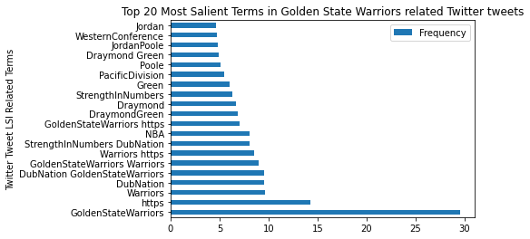

```python
ax = GoldenStateWarriors_LSI_Related_Terms_df.plot.barh(x='Twitter Tweet LSI Related Terms', y='Frequency', title='Top 20 Most Salient Terms in Golden State Warriors related Twitter tweets')
```

# Latent Dirichlet Allocation can be used to specify a probability distribution over multinomials. It helps us answer the question, "What is the probability of observing a given multinomial distribution over k categories?"

```python
lda = LatentDirichletAllocation(n_components = 10, random_state=0)
lda.fit(tf_documents)
topic_models= lda.components_
```

```python
document_train = Warriors_tweet_df['Warriors_Tweet_Text']
```

# Figure 6

```python
num_top_words = 8
def display_topics(model, feature_names, no_top_words):
    for topic_idx, topic in enumerate(model.components_):
        term_list = [feature_names[i]
                        for i in topic.argsort()[:-no_top_words - 1:-1]]
        print("topic %d:" % (topic_idx), term_list)

display_topics(lda, tf_feature_names, num_top_words)
```

```
topic 0: ['warriors', 'nba', 'vs', 'golden', 'state', 'wizards', 'video', 'new']
topic 1: ['warriors', 'goldenstatewarriors', 'dubnation', 'goldenstate', 'nba', 'basketball', 'best', 'gsw']
topic 2: ['klaythompson', 'vs', 'lebronjames', 'stephencurry', 'kevindurant', 'warriors', 'bensimmons', 'damianlillard']
topic 3: ['strengthinnumbers', 'letsgowarriors', 'goldenstate', 'rumors', 'warriors', 'preseason', 'dubs', 'thompson']
topic 4: ['warriors', 'draymond', 'poole', 'green', 'jordan', 'goldenstatewarriors', 'nba', 'draymondgreen']
topic 5: ['warriors', 'lana', 'stevekerr', 'lunafreaks', 'fridaymorning', 'postseason', 'draymond', 'fridayfeeling']
topic 6: ['nba', 'warriors', 'stevekerr', 'basketball', 'dubs', 'goldenstatewarriors', 'nbajapangames', 'stream']
topic 7: ['warriors', 'nba', 'don', 'season', 'team', 'win', 'like', 'year']
topic 8: ['warriors', 'dubs', 'draymond', 'kanye', 'fortheland', 'time', 'nba', 'joseramirez']
topic 9: ['warriors', 'dubs', 'gsw', 'goldenstate', 'letsgowarriors', 'goldenstatewarriors', 'draymondgreen', 'divincenzo']
```

# A Transform can be used on the original document-term matrix to get the document weights per topic

```python
lda_output = lda.transform(tf_documents)
print("LDA transform output:\n", lda_output)
best_document_per_topic = np.argsort(lda_output, axis=0)[::-1]

for topic_index in range(0, 10):
    best_index = best_document_per_topic[0, topic_index]
    print("Highest topic", topic_index, "weight is document", best_index, ":", document_train[best_index][0:20])
```

```
LDA transform output:
 [[0.00769326 0.00769355 0.00769267 ... 0.00769279 0.00769258 0.00769303]
 [0.00555582 0.38762869 0.00555582 ... 0.10692038 0.00555585 0.2454195 ]
 [0.02000734 0.02000626 0.02000153 ... 0.02000239 0.02000183 0.02000202]
 ...
 [0.63024399 0.01000155 0.0100012  ... 0.01000148 0.01000022 0.0100018 ]
 [0.00909161 0.91817387 0.0090931  ... 0.00909171 0.00909121 0.00909278]
 [0.89685075 0.06677999 0.0045466  ... 0.0045456  0.00454598 0.00454714]]
Highest topic 0 weight is document 2311 : new video to watch g
Highest topic 1 weight is document 3985 : football final score
Highest topic 2 weight is document 965 : mnf to get the week
Highest topic 3 weight is document 1175 : if you re a real dub
Highest topic 4 weight is document 2689 : aye yo jordan poole
Highest topic 5 weight is document 4078 : check out 1988 set o
Highest topic 6 weight is document 1222 : os win 82 2 3 frm ny
Highest topic 7 weight is document 4111 : the only players to
Highest topic 8 weight is document 3472 : on 11 12 1964 wilt c
Highest topic 9 weight is document 2600 : klay thompson s 2012
```

# A Word Could is developed to create a better visualization of the word/phrase significances existing that were discovered through LDA

# Figure 9

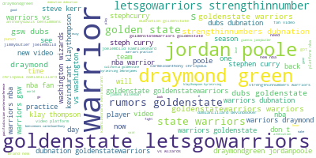

```python
# Join the different processed titles together.
long_string = ','.join(list(document_train.values))
# Create a WordCloud object
wordcloud = WordCloud(background_color="white", max_words=5000, contour_width=3, contour_color='steelblue')
# Generate a word cloud
wordcloud.generate(long_string)
# Visualize the word cloud
wordcloud.to_image()
```

# A pyLDAvis, a visualization specifically designed for LDA analysis, was utilized to provide better observation of the semantic-relationships existing amongst the Golden State Warriors'-related Twitter text data.

# Figure 10

```python
pyLDAvis.enable_notebook()
panel = pyLDAvis.sklearn.prepare(lda, tf_documents, tf_vectorizer, mds='tsne')
panel
```

[interactive chart not shown]

# Another type of text analysis we can conduct to analyse a topic's term weights is Non-negative Matrix Factorization (NMF). We will use NMF on the Golden State Warriors Twitter tweet data and compare its analysis with our results for LDA.

```python
n_topics = 10
X = tfidf_documents
tfidf_feature_names = tfidf_vectorizer.get_feature_names()

nmf = decomposition.NMF(n_components=n_topics, random_state=0, init='nndsvd')
W = nmf.fit_transform(X)
H = nmf.components_

top = 8
topic_index_max = n_topics

for topic_index in range(0, topic_index_max):
    top_indices = np.argsort(H[topic_index, :])[::-1]
    top_terms = []
    for term_index in top_indices[0:top]:
        top_terms.append(tfidf_feature_names[term_index])
    print("topic ", topic_index, top_terms1)
```

[output not shown]

# We can now display the weights from topic 1 while utilizing NMF

# Figure 12

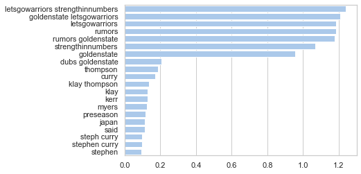

```python
sns.set(style="whitegrid")

topic_index = 1
vocab = np.array(tfidf_feature_names)
top_term_indices = np.array(np.argsort(H[topic_index, :])[::-1])[0:20]

term_strings = vocab[top_term_indices]
term_weights = H[topic_index, top_term_indices]

sns.set_color_codes('pastel')
sns.barplot(x=term_weights, y=term_strings, label='Weight', color='b')

plt.show()
```

# Figure 14

```python
pyLDAvis.enable_notebook()
panel1 = pyLDAvis.sklearn.prepare(nmf, tfidf_documents, tfidf_vectorizer, mds='tsne')
panel1
```

[interactive chart not shown]